# Predicting Loan Eligibility

### Lighthouse Labs, Mini-Project IV.

By Jamie Dormaar

###### January 20, 2023.

## Problem Statement

We want to automate the loan eligibility process based on customer details that are provided as online application forms are being filled. You can find the dataset [here](https://drive.google.com/file/d/1h_jl9xqqqHflI5PsuiQd_soNYxzFfjKw/view?usp=sharing). These details concern the customer's Gender, Marital Status, Education, Number of Dependents, Income, Loan Amount, Credit History and other things as well.

| Variable | Description |
| --- | --- |
| Loan_ID | Unique Loan ID |
| Gender | Male/ Female |
| Married | Applicant married (Y/N) |
| Dependents | Number of dependents |
| Education | Applicant Education (Graduate/ Under Graduate) |
| Self_Employed | Self employed (Y/N) |
| ApplicantIncome | Applicant income |
| CoapplicantIncome | Coapplicant income |
| LoanAmount | Loan amount in thousands |
| Loan_Amount_Term | Term of loan in months |
| Credit_History | credit history meets guidelines |
| Property_Area | Urban/ Semi Urban/ Rural |
| Loan_Status | Loan approved (Y/N) |

### Explore the problem in following stages:

1. Hypothesis Generation – understanding the problem better by brainstorming possible factors that can impact the outcome
2. Data Exploration – looking at categorical and continuous feature summaries and making inferences about the data.
3. Data Cleaning – imputing missing values in the data and checking for outliers
4. Feature Engineering – modifying existing variables and creating new ones for analysis
5. Model Building – making predictive models on the data

## TABLE OF CONTENTS:

1. Hypothesis Generation
2. Data Exploration
   1. Numerical Data Exploration
      1. Distribution Analysis
   2. Categorical Data Exploration
3. Data Cleaning
   1. Imputing Missing Values
   2. Extreme Values
4. Feature Engineering
5. Building a Predictive Model
   1. Parameter Grid Search
6. Using Pipeline
7. Deploy Model to the Cloud
   1. Testing with postman, BASH, or python

## PART 1: Hypothesis Generation

Generating a hypothesis is a major step in the process of analyzing data. This involves understanding the problem and formulating a meaningful hypothesis about what could potentially have a good impact on the outcome. This is done BEFORE looking at the data, and we end up creating a laundry list of the different analyses which we can potentially perform if data is available.

#### Possible hypotheses

Which applicants are more likely to get a loan

1. Applicants having a credit history
2. Applicants with higher applicant and co-applicant incomes
3. Applicants with higher education level
4. Properties in urban areas with high growth perspectives

Do more brainstorming and create some hypotheses of your own. Remember that the data might not be sufficient to test all of these, but forming these enables a better understanding of the problem.

TOP OF PAGE/TOC

## PART 2: Data Exploration

Let's do some basic data exploration here and come up with some inferences about the data. Go ahead and try to figure out some irregularities and address them in the next section.

```python
import pandas as pd
import numpy as np
from matplotlib import pyplot as plt
%matplotlib inline
import seaborn as sns
sns.set_theme()

df_raw = pd.read_csv("../data/data.csv")

df = df_raw.copy()
df.head()
```

|  | Loan_ID | Gender | Married | Dependents | Education | Self_Employed | ApplicantIncome | CoapplicantIncome | LoanAmount | Loan_Amount_Term | Credit_History | Property_Area | Loan_Status |
| --- | --- | --- | --- | --- | --- | --- | --- | --- | --- | --- | --- | --- | --- |
| 0 | LP001002 | Male | No | 0 | Graduate | No | 5849 | 0.0 | NaN | 360.0 | 1.0 | Urban | Y |
| 1 | LP001003 | Male | Yes | 1 | Graduate | No | 4583 | 1508.0 | 128.0 | 360.0 | 1.0 | Rural | N |
| 2 | LP001005 | Male | Yes | 0 | Graduate | Yes | 3000 | 0.0 | 66.0 | 360.0 | 1.0 | Urban | Y |
| 3 | LP001006 | Male | Yes | 0 | Not Graduate | No | 2583 | 2358.0 | 120.0 | 360.0 | 1.0 | Urban | Y |
| 4 | LP001008 | Male | No | 0 | Graduate | No | 6000 | 0.0 | 141.0 | 360.0 | 1.0 | Urban | Y |

One of the key challenges in any data set are missing values. Lets start by checking which columns contain missing values.

```python
# Confirm Loan_ID unique.  If so, it can be dropped for EDA

if df.shape[0]==df['Loan_ID'].nunique():
    print(df.shape)
    df.drop(columns=['Loan_ID'], inplace=True)
    print(df.shape)
```

```
(614, 13)
(614, 12)
```

```python
# Check for nulls:
df_nulls = df.isnull().sum()
perc = round((df_nulls/df.isnull().count())*100,1)
df_missing_data = pd.concat(
    [df_nulls, perc]
  , axis=1
  , keys=['null_cnt', 'null_%']
  , verify_integrity= True
)
# Create Meta data table of Variable details:
meta = df_missing_data.copy()
meta.reset_index(inplace=True, names= 'variable')
meta['dtype'] = list(df.dtypes)

print(f'Shape of data: {df.shape}')
print(f'Nulls in data:')
meta.sort_values('null_%', ascending=False)
```

```
Shape of data: (614, 12)
Nulls in data:
```

|  | variable | null_cnt | null_% | dtype |
| --- | --- | --- | --- | --- |
| 9 | Credit_History | 50 | 8.1 | float64 |
| 4 | Self_Employed | 32 | 5.2 | object |
| 7 | LoanAmount | 22 | 3.6 | float64 |
| 2 | Dependents | 15 | 2.4 | object |
| 8 | Loan_Amount_Term | 14 | 2.3 | float64 |
| 0 | Gender | 13 | 2.1 | object |
| 1 | Married | 3 | 0.5 | object |
| 3 | Education | 0 | 0.0 | object |
| 5 | ApplicantIncome | 0 | 0.0 | int64 |
| 6 | CoapplicantIncome | 0 | 0.0 | float64 |
| 10 | Property_Area | 0 | 0.0 | object |
| 11 | Loan_Status | 0 | 0.0 | object |

```python
# Modularize the above code into a function:
def null_proportions(df, printout=False):
    null = df.isnull().sum()
    perc = round((null/df.isnull().count())*100,1)
    null_df = pd.concat([null, perc]
                        , axis=1
                        , keys=['null_cnt', 'null_%']
                        , verify_integrity= True)
    null_df.reset_index(inplace= True, names= 'variable')
    # Add data type column:
    null_df['dtype'] = list(df.dtypes)

    if printout== True:
        print(f'Shape of data: {df.shape}')
        print(f'Nulls remaining:')
        display(null_df[null_df['null_%']>0
            ].sort_values('null_%', ascending=False))
    return null_df
```

```python
df_null = null_proportions(df, True)
```

```
Shape of data: (614, 12)
Nulls remaining:
```

|  | variable | null_cnt | null_% | dtype |
| --- | --- | --- | --- | --- |
| 9 | Credit_History | 50 | 8.1 | float64 |
| 4 | Self_Employed | 32 | 5.2 | object |
| 7 | LoanAmount | 22 | 3.6 | float64 |
| 2 | Dependents | 15 | 2.4 | object |
| 8 | Loan_Amount_Term | 14 | 2.3 | float64 |
| 0 | Gender | 13 | 2.1 | object |
| 1 | Married | 3 | 0.5 | object |

TOP OF PAGE/TOC

### NUMERICAL VARIABLES:

```python
meta.rename(columns={'index': 'variable'}, inplace=True)
meta
```

|  | variable | null_cnt | null_% | dtype |
| --- | --- | --- | --- | --- |
| 0 | Gender | 13 | 2.1 | object |
| 1 | Married | 3 | 0.5 | object |
| 2 | Dependents | 15 | 2.4 | object |
| 3 | Education | 0 | 0.0 | object |
| 4 | Self_Employed | 32 | 5.2 | object |
| 5 | ApplicantIncome | 0 | 0.0 | int64 |
| 6 | CoapplicantIncome | 0 | 0.0 | float64 |
| 7 | LoanAmount | 22 | 3.6 | float64 |
| 8 | Loan_Amount_Term | 14 | 2.3 | float64 |
| 9 | Credit_History | 50 | 8.1 | float64 |
| 10 | Property_Area | 0 | 0.0 | object |
| 11 | Loan_Status | 0 | 0.0 | object |

```python
numeric = list(df.dtypes[df.dtypes != 'object'].index)
categoric = list(df.dtypes[df.dtypes == 'object'].index)
```

```python
meta_num = pd.DataFrame()
meta_num['sum']     = df[numeric].sum(skipna=True)
meta_num['count']   = df[numeric].count()
meta_num['mean']    = round(df[numeric].mean(skipna=True), 1)
meta_num['std']     = round(df[numeric].std(skipna=True), 1)
meta_num['min']     = df[numeric].min(skipna=True)
meta_num['median']  = df[numeric].median(skipna=True)
meta_num['max']     = df[numeric].max(skipna=True)
meta_num
```

|  | sum | count | mean | std | min | median | max |
| --- | --- | --- | --- | --- | --- | --- | --- |
| ApplicantIncome | 3.317724e+06 | 614 | 5403.5 | 6109.0 | 150.0 | 3812.5 | 81000.0 |
| CoapplicantIncome | 9.954449e+05 | 614 | 1621.2 | 2926.2 | 0.0 | 1188.5 | 41667.0 |
| LoanAmount | 8.667600e+04 | 592 | 146.4 | 85.6 | 9.0 | 128.0 | 700.0 |
| Loan_Amount_Term | 2.052000e+05 | 600 | 342.0 | 65.1 | 12.0 | 360.0 | 480.0 |
| Credit_History | 4.750000e+02 | 564 | 0.8 | 0.4 | 0.0 | 1.0 | 1.0 |

Modularize the code above as a function:

```python
def descriptive_statistics(df):
    num_cols = list(df.dtypes[df.dtypes != 'object'].index)
    dict = {}
    dict['variable'] = list(num_cols)
    dict['sum']      = list(df[num_cols].sum(skipna=True))
    dict['count']    = list(df[num_cols].count())
    dict['mean']     = list(round(df[num_cols].mean(skipna=True), 1))
    dict['std']      = list(round(df[num_cols].std(skipna=True), 1))
    dict['min']      = list(df[num_cols].min(skipna=True))
    dict['median']   = list(df[num_cols].median(skipna=True))
    dict['max']      = list(df[num_cols].max(skipna=True))
    return pd.DataFrame(dict)
```

```python
df_desc_stats = descriptive_statistics(df)
df_desc_stats
```

|  | variable | sum | count | mean | std | min | median | max |
| --- | --- | --- | --- | --- | --- | --- | --- | --- |
| 0 | ApplicantIncome | 3.317724e+06 | 614 | 5403.5 | 6109.0 | 150.0 | 3812.5 | 81000.0 |
| 1 | CoapplicantIncome | 9.954449e+05 | 614 | 1621.2 | 2926.2 | 0.0 | 1188.5 | 41667.0 |
| 2 | LoanAmount | 8.667600e+04 | 592 | 146.4 | 85.6 | 9.0 | 128.0 | 700.0 |
| 3 | Loan_Amount_Term | 2.052000e+05 | 600 | 342.0 | 65.1 | 12.0 | 360.0 | 480.0 |
| 4 | Credit_History | 4.750000e+02 | 564 | 0.8 | 0.4 | 0.0 | 1.0 | 1.0 |

1. How many applicants have a `Credit_History`? (`Credit_History` has value 1 for those who have a credit history and 0 otherwise)

```python
# In addition to the 8% NULL count:
print(df.Credit_History.value_counts())
print(type(df.Credit_History[1]))
```

```
1.0    475
0.0     89
Name: Credit_History, dtype: int64
<class 'numpy.float64'>
```

2. Is the `ApplicantIncome` distribution in line with your expectation? Similarly, what about `CoapplicantIncome`?

```python
df.shape
```

```
(614, 12)
```

```python
df_desc_stats[df_desc_stats['variable'].isin(['ApplicantIncome', 'CoapplicantIncome'])]
```

|  | variable | sum | count | mean | std | min | median | max |
| --- | --- | --- | --- | --- | --- | --- | --- | --- |
| 0 | ApplicantIncome | 3.317724e+06 | 614 | 5403.5 | 6109.0 | 150.0 | 3812.5 | 81000.0 |
| 1 | CoapplicantIncome | 9.954449e+05 | 614 | 1621.2 | 2926.2 | 0.0 | 1188.5 | 41667.0 |

There are surely significant outliers, or at the least a heavily right-skewed distribution for the `ApplicantIncome` considering the discrepancy between the its mean and median values, and how far both of those are from the maximum.

It's interesting that the `CoapplicantIncome`'s standard deviation exceeds the magnitude of its mean by so much. Additionally, the 0 value minimum and low mean values, suggest that the `CoapplicantIncome` might represent individuals receiving assistance in the form of a co-sign designate to enable their loan acquisition.

```python
meta[meta['variable'].isin(['ApplicantIncome', 'CoapplicantIncome'])]
```

|  | variable | null_cnt | null_% | dtype |
| --- | --- | --- | --- | --- |
| 5 | ApplicantIncome | 0 | 0.0 | int64 |
| 6 | CoapplicantIncome | 0 | 0.0 | float64 |

3. Tip: Can you see a possible skewness in the data by comparing the mean to the median, i.e. the 50% figure of a feature.

```python
# Will use the Shapiro Wilk Normailiy test to test the
# H0: The distribution is normal: mean = median
from scipy import stats

def shapiro_normality(df, col_name):
    from scipy import stats
    stat, p = stats.shapiro(df[col_name])
    h0_keep = (f"{col_name} Normality:\n  Evidence insufficient to reject H0 as p < 0.05 = False:  p:{'%0.5f' % p}, stat: {round(stat, 3)}")
    h0_rej = (f"{col_name} Normality:\n  Likely Gaussian, H0 rejected: p:{'%0.5f' % p}, stat: {round(stat, 3)}")
    return h0_rej if p < 0.05 else h0_keep
```

```python
print(shapiro_normality(df, 'ApplicantIncome'))
print(shapiro_normality(df, 'CoapplicantIncome'))
```

[output not shown]

TOP OF PAGE/TOC

#### DISTRIBUTION ANALYSIS:

Study distribution of various variables. Plot the histogram of ApplicantIncome, try different number of bins.

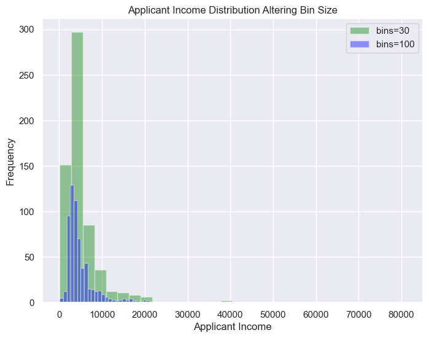

```python
x = df['ApplicantIncome']

plt.figure(figsize=(8,6))
plt.hist(x, bins=30, alpha=0.4, label="bins=30", color= 'green')
plt.hist(x, bins=100, alpha=0.4, label="bins=100", color= 'blue')

plt.xlabel('Applicant Income', size=12)
plt.xlabel('Applicant Income', size=12)
plt.ylabel('Frequency')
plt.title('Applicant Income Distribution Altering Bin Size')
plt.legend(loc='upper right')
plt.grid(True)
plt.show()
```

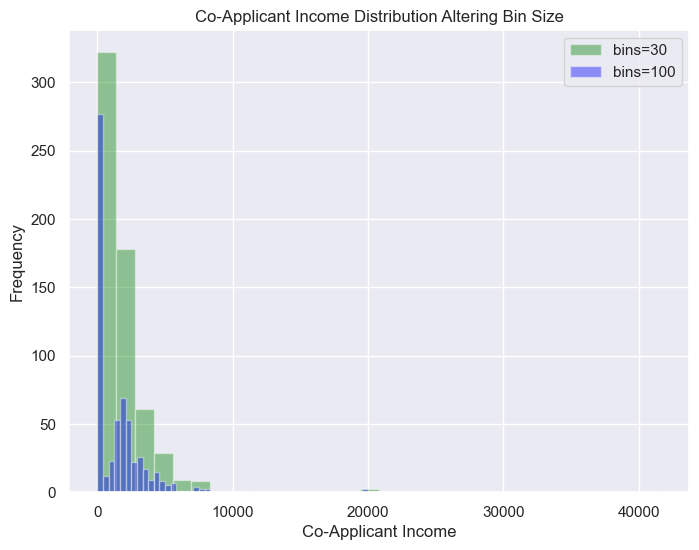

```python
x = df['CoapplicantIncome']

plt.figure(figsize=(8,6))
plt.hist(x, bins=30, alpha=0.4, label="bins=30", color= 'green')
plt.hist(x, bins=100, alpha=0.4, label="bins=100", color= 'blue')

plt.xlabel('Co-Applicant Income', size=12)
plt.xlabel('Co-Applicant Income', size=12)
plt.ylabel('Frequency')
plt.title('Co-Applicant Income Distribution Altering Bin Size')
plt.legend(loc='upper right')
plt.grid(True)
plt.show()
```

As Suggested previously, the significant number of 0 value Co-Applicant Incomes is likely representing the number of applicants without a co-sign applicant, and so we can likely combine the CoapplicantIncome values with ApplicantIncome values:

```python
df.head()
```

|  | Gender | Married | Dependents | Education | Self_Employed | ApplicantIncome | CoapplicantIncome | LoanAmount | Loan_Amount_Term | Credit_History | Property_Area | Loan_Status |
| --- | --- | --- | --- | --- | --- | --- | --- | --- | --- | --- | --- | --- |
| 0 | Male | No | 0 | Graduate | No | 5849 | 0.0 | NaN | 360.0 | 1.0 | Urban | Y |
| 1 | Male | Yes | 1 | Graduate | No | 4583 | 1508.0 | 128.0 | 360.0 | 1.0 | Rural | N |
| 2 | Male | Yes | 0 | Graduate | Yes | 3000 | 0.0 | 66.0 | 360.0 | 1.0 | Urban | Y |
| 3 | Male | Yes | 0 | Not Graduate | No | 2583 | 2358.0 | 120.0 | 360.0 | 1.0 | Urban | Y |
| 4 | Male | No | 0 | Graduate | No | 6000 | 0.0 | 141.0 | 360.0 | 1.0 | Urban | Y |

```python
df['combined_incomes'] = df['CoapplicantIncome'] + df['ApplicantIncome']
df.head()
```

|  | Gender | Married | Dependents | Education | Self_Employed | ApplicantIncome | CoapplicantIncome | LoanAmount | Loan_Amount_Term | Credit_History | Property_Area | Loan_Status | combined_incomes |
| --- | --- | --- | --- | --- | --- | --- | --- | --- | --- | --- | --- | --- | --- |
| 0 | Male | No | 0 | Graduate | No | 5849 | 0.0 | NaN | 360.0 | 1.0 | Urban | Y | 5849.0 |
| 1 | Male | Yes | 1 | Graduate | No | 4583 | 1508.0 | 128.0 | 360.0 | 1.0 | Rural | N | 6091.0 |
| 2 | Male | Yes | 0 | Graduate | Yes | 3000 | 0.0 | 66.0 | 360.0 | 1.0 | Urban | Y | 3000.0 |
| 3 | Male | Yes | 0 | Not Graduate | No | 2583 | 2358.0 | 120.0 | 360.0 | 1.0 | Urban | Y | 4941.0 |
| 4 | Male | No | 0 | Graduate | No | 6000 | 0.0 | 141.0 | 360.0 | 1.0 | Urban | Y | 6000.0 |

Look at box plots to understand the distributions.

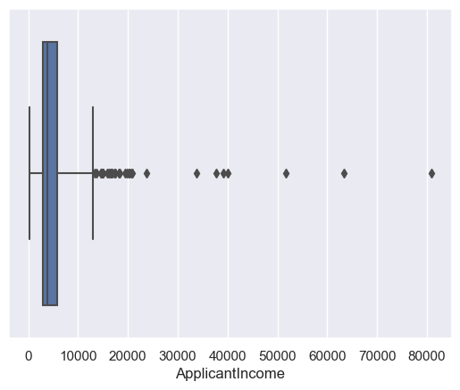

```python
x = df
sns.boxplot(data= x, x='ApplicantIncome', whis= 2.5)
```

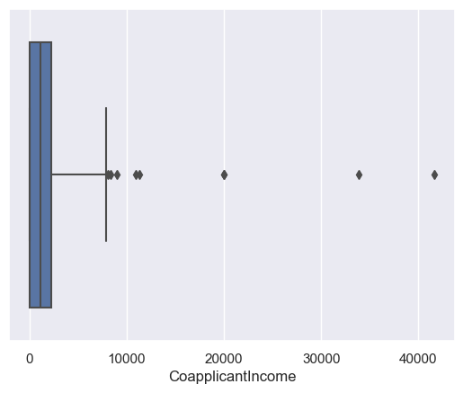

```python
sns.boxplot(data= x, x='CoapplicantIncome', whis= 2.5)
```

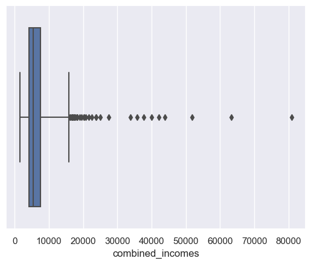

```python
sns.boxplot(data= x, x='combined_incomes', whis= 2.5)
```

```python
list(df[numeric].columns)
```

```
['ApplicantIncome',
 'CoapplicantIncome',
 'LoanAmount',
 'Loan_Amount_Term',
 'Credit_History']
```

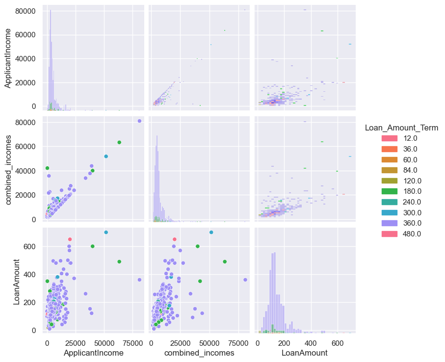

```python
x = df[['ApplicantIncome', 'combined_incomes', 'LoanAmount', 'Loan_Amount_Term']]
# sns.pairplot(x, hue="Loan_Amount_Term", diag_kind="hist")

g = sns.pairplot(x
    , kind='hist'
    , hue='Loan_Amount_Term'
    , height=2.5
    , aspect=1
    , dropna=True
    ,palette='husl')

g.map_lower(sns.scatterplot)
```

Look at the distribution of income segregated by `Education`

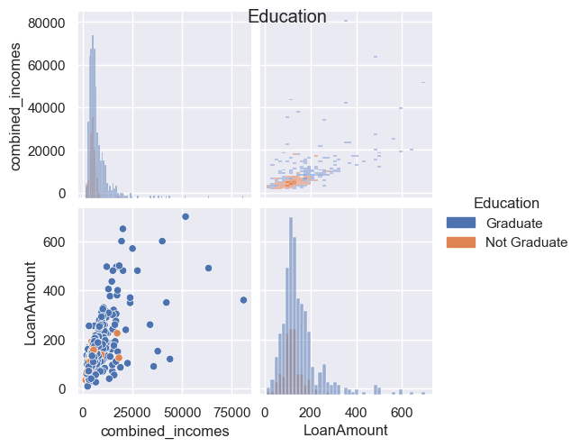

```python
x = df[['combined_incomes', 'Education', 'LoanAmount']]

g = sns.pairplot(x
    , kind='hist'
    , hue='Education'
    , height=2.5
    , aspect=1
    , dropna=True
    )

g.map_lower(sns.scatterplot)
g.fig.suptitle('Education')
```

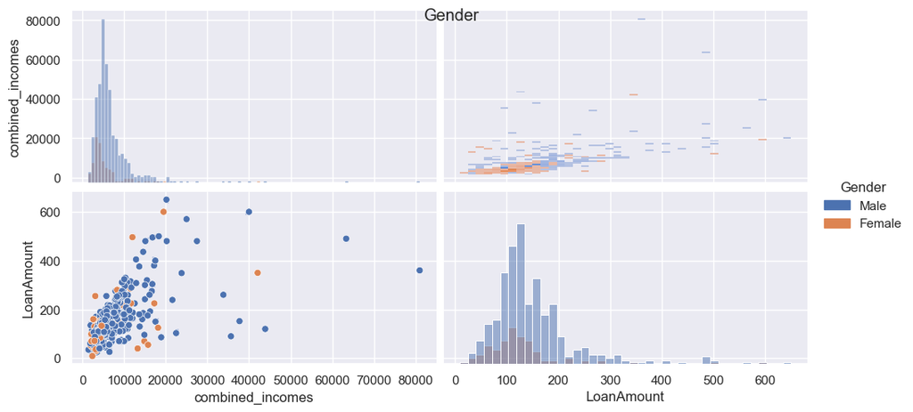

```python
x = df[['combined_incomes', 'Gender', 'LoanAmount']]

g = sns.pairplot(x
    , kind='hist'
    , hue='Gender'
    , height=2.5
    , aspect=2
    , dropna=True
    )

g.map_lower(sns.scatterplot)
g.fig.suptitle('Gender')
```

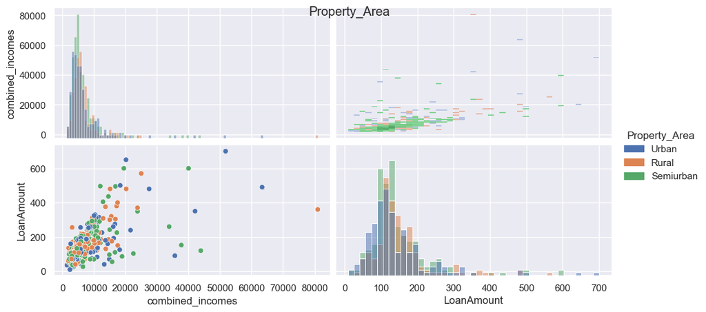

```python
x = df[['combined_incomes', 'Property_Area', 'LoanAmount']]

g = sns.pairplot(x
    , kind='hist'
    , hue='Property_Area'
    , height=2.5
    , aspect=2
    , dropna=True
    )

g.map_lower(sns.scatterplot)
g.fig.suptitle('Property_Area')
```

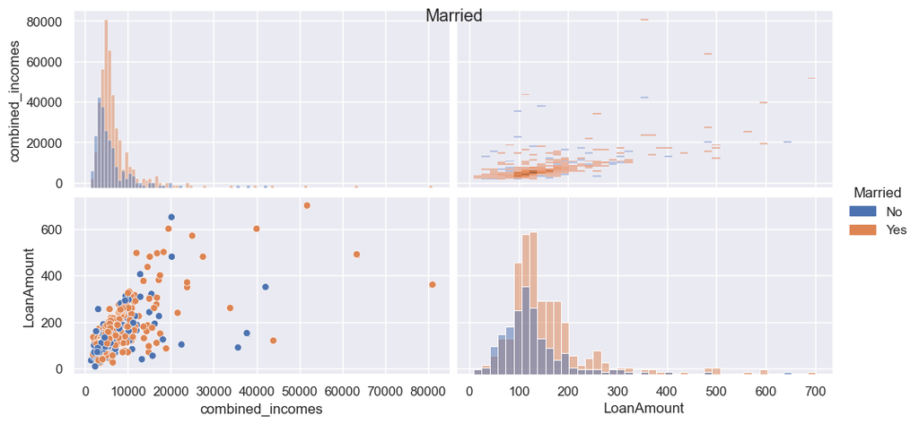

```python
x = df[['combined_incomes', 'Married', 'LoanAmount']]

g = sns.pairplot(x
    , kind='hist'
    , hue='Married'
    , height=2.5
    , aspect=2
    , dropna=True
    )

g.map_lower(sns.scatterplot)
g.fig.suptitle('Married')
```

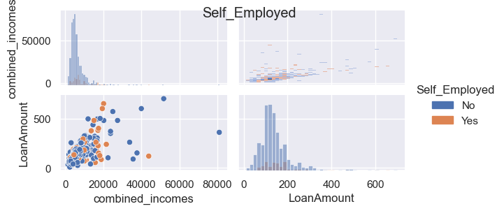

```python
x = df[['combined_incomes', 'Self_Employed', 'LoanAmount']]

g = sns.pairplot(x
    , kind='hist'
    , hue='Self_Employed'
    , height=1.5
    , aspect=2
    , dropna=True
    )

g.map_lower(sns.scatterplot)
g.fig.suptitle('Self_Employed')
```

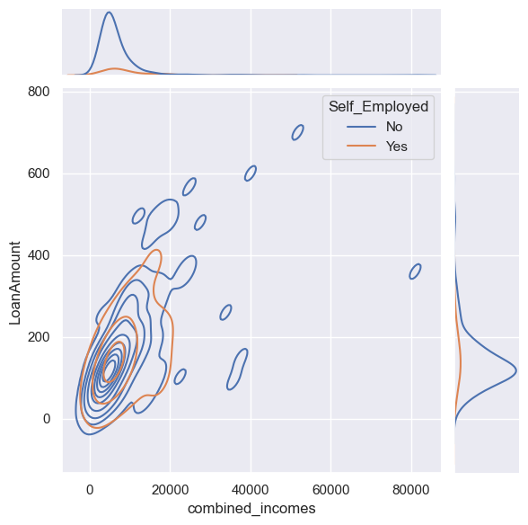

```python
x = df[['combined_incomes', 'Self_Employed', 'LoanAmount']]

sns.jointplot(data=x, x="combined_incomes", y="LoanAmount", hue="Self_Employed", kind="kde")
```

Look at the histogram and boxplot of LoanAmount

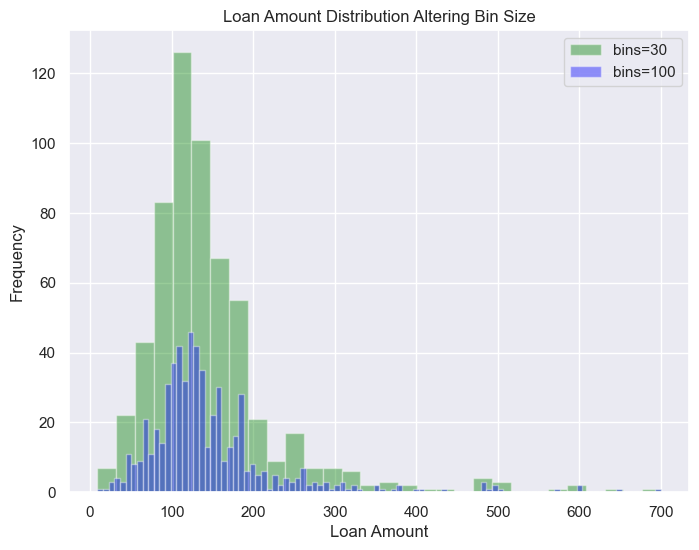

```python
x = df['LoanAmount']

plt.figure(figsize=(8,6), )
plt.hist(x, bins=30, alpha=0.4, label="bins=30", color= 'green')
plt.hist(x, bins=100, alpha=0.4, label="bins=100", color= 'blue')

plt.xlabel('Loan Amount', size=12)
plt.ylabel('Frequency')
plt.title('Loan Amount Distribution Altering Bin Size')
plt.legend(loc='upper right')
plt.grid(True)
plt.show()
```

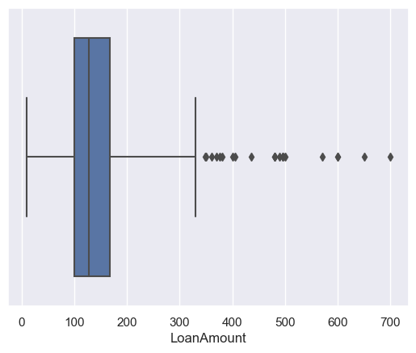

```python
# Outlier detection:
x = df
sns.boxplot(data= x, x='LoanAmount', whis= 2.5)

# plt.savefig(f'../Images/Arrival_delay_outliers_boxplot_{session}.png')
```

There might be some extreme values. Both `ApplicantIncome` and `LoanAmount` require some amount of data munging. `LoanAmount` has missing and well as extreme values values, while `ApplicantIncome` has a few extreme values, which demand deeper understanding.

```python
#Log transform of right skewed data
df["log_LoanAmount"] = df["LoanAmount"].apply(np.log)
df["log_ApplicantIncome"] = df["ApplicantIncome"].apply(np.log)
df["log_combined_incomes"] = df["combined_incomes"].apply(np.log)
df["log_CoapplicantIncome"] = df["CoapplicantIncome"].add(0.001).apply(np.log)
```

```python
def hist_compare(df, col1, col2):
  fig, axes = plt.subplots(1, 2, figsize = (10,3))
  # Plot 0:
  axes[0].hist(df[col1], bins=40, alpha=0.4, label="bins=40", color= 'green')
  axes[0].hist(df[col1], bins=80, alpha=0.4, label="bins=80", color= 'blue')
  axes[0].legend(loc='upper right')
  axes[0].set_title(f'Histogram of {col1}')
  axes[0].set_xlabel(col1)
  axes[0].set_ylabel('Count Frequency')

  # Plot 1:
  axes[1].hist(df[col2], bins=40, alpha=0.4, label="bins=40", color= 'green')
  axes[1].hist(df[col2], bins=80, alpha=0.4, label="bins=80", color= 'blue')
  axes[1].legend(loc='upper right')
  axes[1].set_title(f'Histogram of {col2}')
  axes[1].set_xlabel(col2)
  axes[1].set_ylabel('Count Frequency')
  plt.savefig(f'../images/hist_compare_{col1}_{col2}.png')
  plt.show()
```

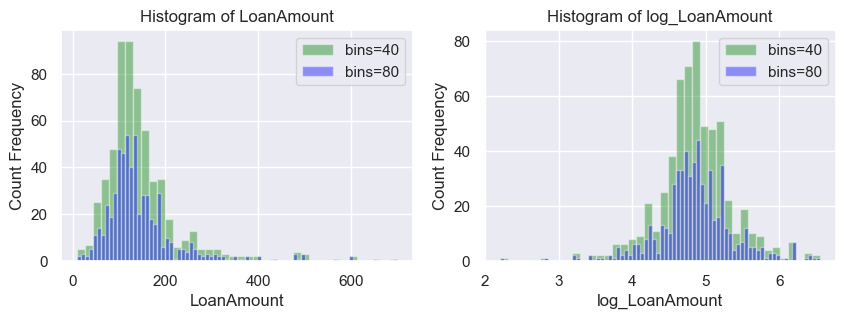

```
None
```

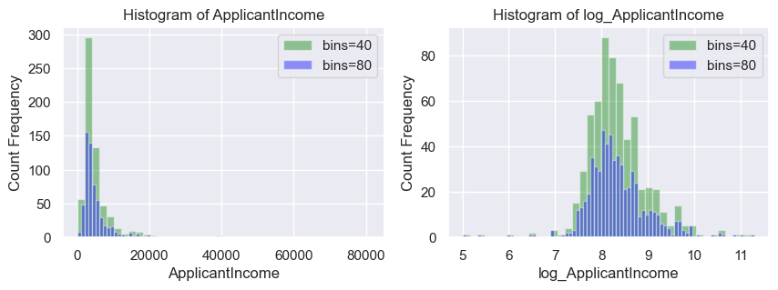

```
None
```

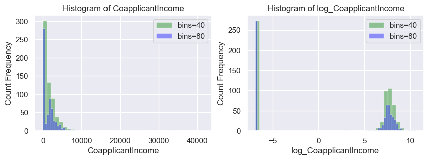

```
None
```

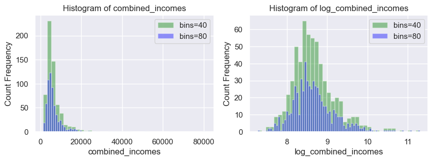

```
None
```

```python
print(hist_compare(df, 'LoanAmount', 'log_LoanAmount'))
print(hist_compare(df, 'ApplicantIncome', 'log_ApplicantIncome'))
print(hist_compare(df, 'CoapplicantIncome', 'log_CoapplicantIncome'))
print(hist_compare(df, 'combined_incomes', 'log_combined_incomes'))
```

```python
def boxplot_compare2_x(df, col1, col2):
  fig, axes = plt.subplots(1, 2, figsize = (10,2))
  # Plot 0:
  sns.boxplot(ax = axes[0], data= df, x=col1, whis= 2.5)

  # Plot 1:
  sns.boxplot(ax = axes[1], data= df, x=col2, whis= 2.5)
  plt.savefig(f'../images/boxplot_compare2_x_{col1}_{col2}.png')
  plt.show()
```

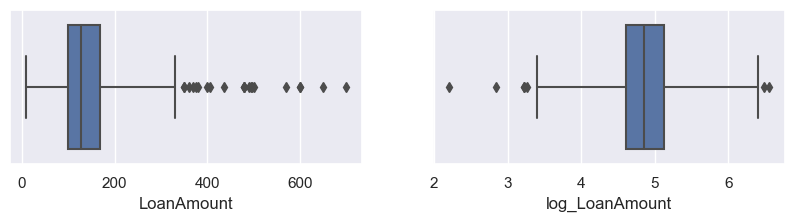

```
None
```

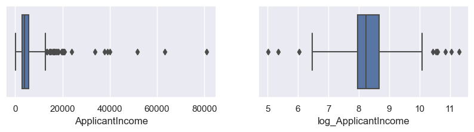

```
None
```

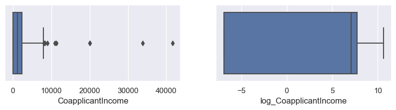

```
None
```

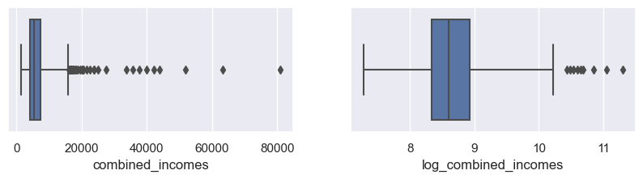

```
None
```

```python
print(boxplot_compare2_x(df, 'LoanAmount', 'log_LoanAmount'))
print(boxplot_compare2_x(df, 'ApplicantIncome', 'log_ApplicantIncome'))
print(boxplot_compare2_x(df, 'CoapplicantIncome', 'log_CoapplicantIncome'))
print(boxplot_compare2_x(df, 'combined_incomes', 'log_combined_incomes'))
```

It doesn't appear as though the separated income values add any enrichment to the income distribution data, and it's clear from the boxplots above that:

- the lower income outliers are accounted for by their co-signature applicants, and
- the `combined_incomes` resolves the co-applicant 0 income related distortions.

The presence or absence of the co-applicant may yet have value, so `second_applicant` classification value is added before dropping both columns.

```python
pos_coapps = df[df['CoapplicantIncome']>0]
df['CoapplicantIncome'] = pos_coapps['CoapplicantIncome']**0
df['second_applicant'] = df['CoapplicantIncome'].fillna(0)
df.head()
```

|  | Gender | Married | Dependents | Education | Self_Employed | ApplicantIncome | CoapplicantIncome | LoanAmount | Loan_Amount_Term | Credit_History | Property_Area | Loan_Status | combined_incomes | log_LoanAmount | log_ApplicantIncome | log_combined_incomes | log_CoapplicantIncome | second_applicant |
| --- | --- | --- | --- | --- | --- | --- | --- | --- | --- | --- | --- | --- | --- | --- | --- | --- | --- | --- |
| 0 | Male | No | 0 | Graduate | No | 5849 | NaN | NaN | 360.0 | 1.0 | Urban | Y | 5849.0 | NaN | 8.674026 | 8.674026 | -6.907755 | 0.0 |
| 1 | Male | Yes | 1 | Graduate | No | 4583 | 1.0 | 128.0 | 360.0 | 1.0 | Rural | N | 6091.0 | 4.852030 | 8.430109 | 8.714568 | 7.318540 | 1.0 |
| 2 | Male | Yes | 0 | Graduate | Yes | 3000 | NaN | 66.0 | 360.0 | 1.0 | Urban | Y | 3000.0 | 4.189655 | 8.006368 | 8.006368 | -6.907755 | 0.0 |
| 3 | Male | Yes | 0 | Not Graduate | No | 2583 | 1.0 | 120.0 | 360.0 | 1.0 | Urban | Y | 4941.0 | 4.787492 | 7.856707 | 8.505323 | 7.765570 | 1.0 |
| 4 | Male | No | 0 | Graduate | No | 6000 | NaN | 141.0 | 360.0 | 1.0 | Urban | Y | 6000.0 | 4.948760 | 8.699515 | 8.699515 | -6.907755 | 0.0 |

```python
df.head()
```

|  | Gender | Married | Dependents | Education | Self_Employed | ApplicantIncome | CoapplicantIncome | LoanAmount | Loan_Amount_Term | Credit_History | Property_Area | Loan_Status | combined_incomes | log_LoanAmount | log_ApplicantIncome | log_combined_incomes | log_CoapplicantIncome | second_applicant |
| --- | --- | --- | --- | --- | --- | --- | --- | --- | --- | --- | --- | --- | --- | --- | --- | --- | --- | --- |
| 0 | Male | No | 0 | Graduate | No | 5849 | NaN | NaN | 360.0 | 1.0 | Urban | Y | 5849.0 | NaN | 8.674026 | 8.674026 | -6.907755 | 0.0 |
| 1 | Male | Yes | 1 | Graduate | No | 4583 | 1.0 | 128.0 | 360.0 | 1.0 | Rural | N | 6091.0 | 4.852030 | 8.430109 | 8.714568 | 7.318540 | 1.0 |
| 2 | Male | Yes | 0 | Graduate | Yes | 3000 | NaN | 66.0 | 360.0 | 1.0 | Urban | Y | 3000.0 | 4.189655 | 8.006368 | 8.006368 | -6.907755 | 0.0 |
| 3 | Male | Yes | 0 | Not Graduate | No | 2583 | 1.0 | 120.0 | 360.0 | 1.0 | Urban | Y | 4941.0 | 4.787492 | 7.856707 | 8.505323 | 7.765570 | 1.0 |
| 4 | Male | No | 0 | Graduate | No | 6000 | NaN | 141.0 | 360.0 | 1.0 | Urban | Y | 6000.0 | 4.948760 | 8.699515 | 8.699515 | -6.907755 | 0.0 |

```python
df = df[df.columns[~df.columns.isin([
      'ApplicantIncome'
    , 'log_ApplicantIncome'
    , 'CoapplicantIncome'
    , 'log_CoapplicantIncome'])]]
df.head()
```

|  | Gender | Married | Dependents | Education | Self_Employed | LoanAmount | Loan_Amount_Term | Credit_History | Property_Area | Loan_Status | combined_incomes | log_LoanAmount | log_combined_incomes | second_applicant |
| --- | --- | --- | --- | --- | --- | --- | --- | --- | --- | --- | --- | --- | --- | --- |
| 0 | Male | No | 0 | Graduate | No | NaN | 360.0 | 1.0 | Urban | Y | 5849.0 | NaN | 8.674026 | 0.0 |
| 1 | Male | Yes | 1 | Graduate | No | 128.0 | 360.0 | 1.0 | Rural | N | 6091.0 | 4.852030 | 8.714568 | 1.0 |
| 2 | Male | Yes | 0 | Graduate | Yes | 66.0 | 360.0 | 1.0 | Urban | Y | 3000.0 | 4.189655 | 8.006368 | 0.0 |
| 3 | Male | Yes | 0 | Not Graduate | No | 120.0 | 360.0 | 1.0 | Urban | Y | 4941.0 | 4.787492 | 8.505323 | 1.0 |
| 4 | Male | No | 0 | Graduate | No | 141.0 | 360.0 | 1.0 | Urban | Y | 6000.0 | 4.948760 | 8.699515 | 0.0 |

```
(-0.5, 2.5, 0.0, 800.0)
```

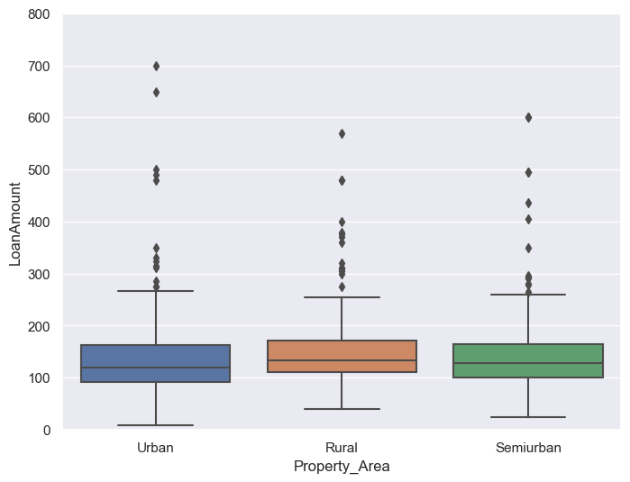

```python
# Property_Area
var = 'Property_Area'
data = df[['LoanAmount',var]]
f, ax = plt.subplots(figsize=(8, 6))
fig = sns.boxplot(x=var, y="LoanAmount", data=data)
fig.axis(ymin=-0, ymax=800)
```

```
(-0.5, 1.5, 0.0, 700.0)
```

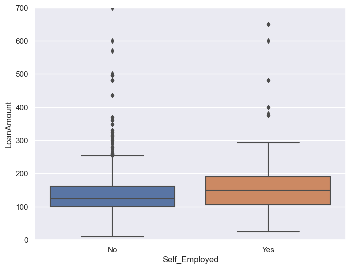

```python
# Self_Employed
var = 'Self_Employed'
data = df[['LoanAmount',var]]
f, ax = plt.subplots(figsize=(8, 6))
fig = sns.boxplot(x=var, y="LoanAmount", data=data)
fig.axis(ymin=-0, ymax=700)
```

TOP OF PAGE/TOC

### CATEGORICAL VARIABLES:

Try to understand categorical variables in more details using `pandas.DataFrame.pivot_table` and some visualizations.

Let's discuss nominal (categorical) variable. Look at the number of unique values in each of them.

```python
cats = list(df.dtypes[df.dtypes == 'object'].index)
dict = {}
dict['variable'] = list(cats)
dict['nunique'] = df[cats].nunique()
# dict['val_cnts'] = df[cats].value_counts()
pd.DataFrame(dict)
```

|  | variable | nunique |
| --- | --- | --- |
| Gender | Gender | 2 |
| Married | Married | 2 |
| Dependents | Dependents | 4 |
| Education | Education | 2 |
| Self_Employed | Self_Employed | 2 |
| Property_Area | Property_Area | 3 |
| Loan_Status | Loan_Status | 2 |

Number of variable counts for each nominal sub category:

```python
df.dtypes[df.dtypes == 'object']
```

```
Gender           object
Married          object
Dependents       object
Education        object
Self_Employed    object
Property_Area    object
Loan_Status      object
dtype: object
```

```python
cats = df.dtypes[df.dtypes == 'object'].index
dict = {}
for var in cats:
    var_dict = df[var].value_counts().to_dict()
    dict[var] = var_dict

dict
```

```
{'Gender': {'Male': 489, 'Female': 112},
 'Married': {'Yes': 398, 'No': 213},
 'Dependents': {'0': 345, '1': 102, '2': 101, '3+': 51},
 'Education': {'Graduate': 480, 'Not Graduate': 134},
 'Self_Employed': {'No': 500, 'Yes': 82},
 'Property_Area': {'Semiurban': 233, 'Urban': 202, 'Rural': 179},
 'Loan_Status': {'Y': 422, 'N': 192}}
```

```python
multi_index_dict = {
    (outerKey, innerKey): values for outerKey, innerDict in dict.items() for innerKey, values in innerDict.items()}
multi_index_dict
```

```
{('Gender', 'Male'): 489,
 ('Gender', 'Female'): 112,
 ('Married', 'Yes'): 398,
 ('Married', 'No'): 213,
 ('Dependents', '0'): 345,
 ('Dependents', '1'): 102,
 ('Dependents', '2'): 101,
 ('Dependents', '3+'): 51,
 ('Education', 'Graduate'): 480,
 ('Education', 'Not Graduate'): 134,
 ('Self_Employed', 'No'): 500,
 ('Self_Employed', 'Yes'): 82,
 ('Property_Area', 'Semiurban'): 233,
 ('Property_Area', 'Urban'): 202,
 ('Property_Area', 'Rural'): 179,
 ('Loan_Status', 'Y'): 422,
 ('Loan_Status', 'N'): 192}
```

```python
multi_index_df = pd.DataFrame.from_dict(dict, orient="index", ).stack().to_frame()
multi_index_df
```

|  |  | 0 |
| --- | --- | --- |
| Gender | Male | 489.0 |
|  | Female | 112.0 |
| Married | Yes | 398.0 |
|  | No | 213.0 |
| Self_Employed | Yes | 82.0 |
|  | No | 500.0 |
| Dependents | 0 | 345.0 |
|  | 1 | 102.0 |
|  | 2 | 101.0 |
|  | 3+ | 51.0 |
| Education | Graduate | 480.0 |
|  | Not Graduate | 134.0 |
| Property_Area | Semiurban | 233.0 |
|  | Urban | 202.0 |
|  | Rural | 179.0 |
| Loan_Status | Y | 422.0 |
|  | N | 192.0 |

Explore further using the frequency of different categories in each nominal variable. Exclude the ID obvious reasons.

```python
df_categ = df[df.columns[~df.columns.isin(['Loan_ID'])]]
df_categ.head()
```

|  | Gender | Married | Dependents | Education | Self_Employed | LoanAmount | Loan_Amount_Term | Credit_History | Property_Area | Loan_Status | combined_incomes | log_LoanAmount | log_combined_incomes | second_applicant |
| --- | --- | --- | --- | --- | --- | --- | --- | --- | --- | --- | --- | --- | --- | --- |
| 0 | Male | No | 0 | Graduate | No | NaN | 360.0 | 1.0 | Urban | Y | 5849.0 | NaN | 8.674026 | 0.0 |
| 1 | Male | Yes | 1 | Graduate | No | 128.0 | 360.0 | 1.0 | Rural | N | 6091.0 | 4.852030 | 8.714568 | 1.0 |
| 2 | Male | Yes | 0 | Graduate | Yes | 66.0 | 360.0 | 1.0 | Urban | Y | 3000.0 | 4.189655 | 8.006368 | 0.0 |
| 3 | Male | Yes | 0 | Not Graduate | No | 120.0 | 360.0 | 1.0 | Urban | Y | 4941.0 | 4.787492 | 8.505323 | 1.0 |
| 4 | Male | No | 0 | Graduate | No | 141.0 | 360.0 | 1.0 | Urban | Y | 6000.0 | 4.948760 | 8.699515 | 0.0 |